# R Notebook

Jacob Hallowell

# Setup

```r
# clean up workspace environment
rm(list = ls())

# all packages used for the assignment
library(mosaic)
library(tidyverse)
```

The goal of this test is to create the Runs Created Stat for the Ground Sloths, as well as an attempt to visualize other stats.

```r
sloths_stat <- read.csv('sloths CSVs/sloths_6-3.csv', skip = 1, header = TRUE)
```

This loads in any file we choose on the computer. It also formats the file as long as it is a CSV from gamechanger.

With all of these columns of data it makes it hard to mutate and add columns like RC. I could attempt to remove pitching stats but still. I think the best thing to do is to create new separate tables and map from there.

For example, I am going to create a new table selecting only the stats I want.

```r
hit_stats <-
  sloths_stat %>%
  select("Number","First","Last","GP","PA","AB","X1B","X2B","X3B","H","HR","RBI","R","BB","SO","AVG","OBP","SLG","OPS","SB","XBH","TB")

hit_stats <- transform(hit_stats, GP = as.numeric(GP),
                       PA = as.numeric(PA),
                       AB = as.numeric(AB),
                       X1B = as.numeric(X1B),
                       X2B = as.numeric(X2B),
                       X3B = as.numeric(X3B),
                       H = as.numeric(H),
                       HR = as.numeric(HR),
                       BB = as.numeric(BB),
                       SO = as.numeric(SO),
                       AVG = as.numeric(AVG),
                       OBP = as.numeric(OBP),
                       SLG = as.numeric(SLG),
                       OPS = as.numeric(OPS),
                       SB = as.numeric(SB),
                       XBH = as.numeric(XBH),
                       TB = as.numeric(TB))
hit_stats <- hit_stats[-c(25,26, 27), ]
```

```r
filteredhitters <-
  hit_stats %>%
  filter(PA > 2)
```

This also sorts out the HR hitters and pitchers.

# Making Runs Created

There are a few things that go into Runs Created

- Total Bases (TB)
- Walks (BB)
- Hits (H)
- At-bats (AB)

There are a few ways to illustrate Run Created without actually making the stat yet. First, we visualize Walks vs Total bases. For these examples we will be using the Ground Sloths roster.

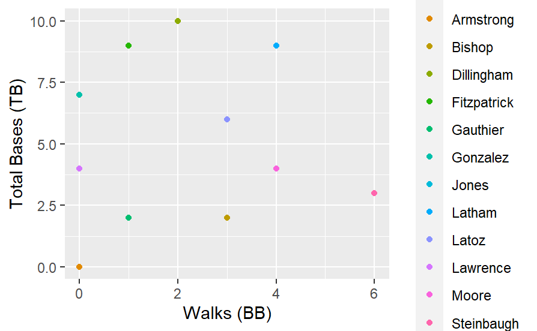

```r
filteredhitters %>%
  ggplot(aes(x = BB, y = TB, color = Last)) +
  geom_point() +
  xlab("Walks (BB)") +
  ylab("Total Bases (TB)")
```

So there is no direct correlation between walks and total bases. It would look like this for other things such as hits.

However, we want to look at something like average vs total bases. This raises the question does more hits really mean more total bases.

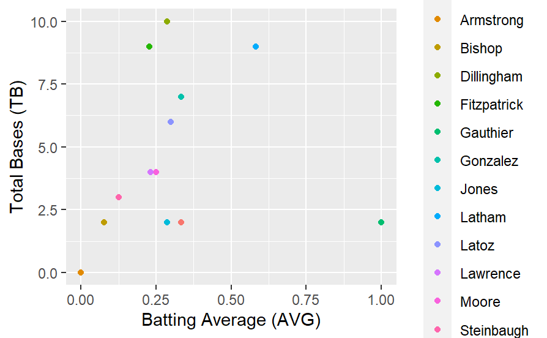

```r
filteredhitters %>%
  ggplot(aes(x = AVG, y = TB, color = Last)) +
  geom_point() +
  xlab("Batting Average (AVG)") +
  ylab("Total Bases (TB)")
```

Now we want to create our Runs Created stat.

```r
filteredhitters <-
  filteredhitters %>%
  mutate(RC = TB * ((H + BB)/(AB + BB)))

filteredhitters %>%
  arrange(desc(RC)) %>%
  select("First","Last","RC") %>%
  head(10)
```

|  | First | Last | RC |
| --- | --- | --- | --- |
| 1 | Jon | Latham | 6.1875000 |
| 2 | Peyton | Dillingham | 3.4782609 |
| 3 | Garrett | Latoz | 2.7692308 |
| 4 | Davey | Fitzpatrick | 2.3478261 |
| 5 | Gavin | Gonzalez | 2.3333333 |
| 6 | JP | Gauthier | 2.0000000 |
| 7 | Eli | Moore | 1.6000000 |
| 8 | Cale | Steinbaugh | 1.0909091 |
| 9 | Chase | Adams | 1.0000000 |
| 10 | Luke | Lawrence | 0.9230769 |

So after all that work we find that Jon Latham is the team leader in Runs Created with just above 6. The RC stat helps us figure out how many runs players create at the plate.